# World Happiness Report

Are We Really Happy!!!

Mohamed Gad

2024-10-29

# 1 Intro

Entering this data analysis with a darkly comedic lens, I’ll say this: we’re supposedly living in one of humanity’s “peaceful” eras, though I’ve got zero data to back that. Curious about how peaceful things really are? I am too, and it’s why I’m here.

Looking around, we’ve got the UK—once a mighty empire, now post-Brexit, clutching onto Northern Ireland like a worn-out keepsake from better days. France, meanwhile, faces regular unrest, spiced up by occasional cultural clashes at events. Then there’s Russia, leaning on Ukraine not just out of nostalgia but for gas revenue—why pay transit fees when you can just occupy the tollbooth?

In the Middle East, the Israeli-Palestinian conflict rages on while Egypt and Ethiopia trade cold stares across the Nile, both nations seemingly unaware they last contributed to humanity’s progress about 1,500 years ago. And in the U.S., the battleground is one of identity crises and economic yo-yos that make even egg prices seem mercurial. Maybe it’s time to retire the whole two-party and electoral college thing while we’re at it.

Despite it all, maybe this is what “peaceful” looks like in 2024—a world where we replace sword fights with strategic sanctions, passive-aggressive summit shade, and internet memes. So, let’s dig into the data and see if our “peace” translates into actual happiness. For this, I’ll be using R for data exploration, Python for machine learning, and the MERN stack for a polished presentation.

# 2 Exploratory Data Analysis

The dataset covers the years from **2005** to **2023**, analyzing six key variables and their associations with life evaluations across countries. These variables include GDP per capita, social support, healthy life expectancy, freedom, generosity, and perceived corruption. The happiness rankings are not derived from a composite index of these factors; instead, they are based on individuals’ self-assessments using the Cantril Ladder question. This approach is similar to how epidemiologists study life expectancy by examining influences like smoking, exercise, and diet to understand variation in health outcomes.

This analysis spans **165** countries worldwide, offering a comprehensive, ground-level perspective on global socio-economic and political realities as observed by residents. By examining life evaluations across diverse settings, we gain insights into how different cultural, economic, and political environments influence individual well-being. These country-specific observations provide a realistic snapshot of the world, illuminating both universal patterns and unique, localized trends in happiness and life satisfaction. This broad dataset allows us to see beyond averages, capturing the range of human experience across vastly different nations and contexts.

## 2.1 Life Ladder

While examining the dataset, I couldn’t resist first checking out the **20** countries that rank lowest on the life ladder scale. The graph below reveals these nations, showing us where life satisfaction may be at its most challenged.

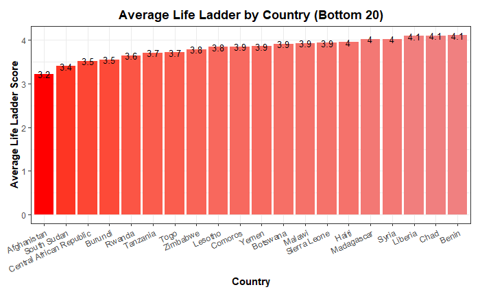

Turning to the dataset, I started by exploring the 20 countries that top the life ladder scale. The graph below highlights these nations, offering a glimpse into where life satisfaction levels soar the highest.

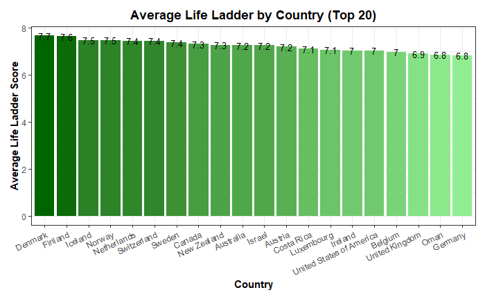

## 2.2 GDP Per Capita

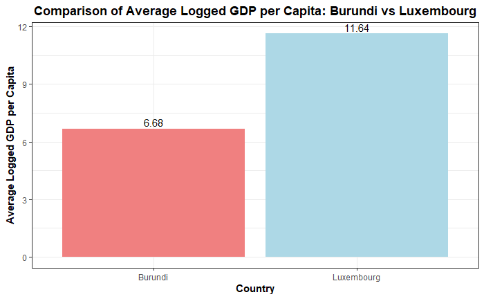

## 2.3 Social Support

The map below, titled “Global Social Support by Country,” provides a visual representation of social support levels worldwide. The color gradient highlights variations in social support across different regions:

- *Higher social support* is represented in shades of green, with countries in North America, Europe, and parts of South America showing robust support networks.
- *Lower social support* appears in shades of red and orange, particularly in regions like South Asia (e.g., India) and parts of Africa.
- *Grey areas* indicate countries where data is unavailable, leaving gaps in the global view, especially in regions of the Middle East and some African countries.

This map effectively illustrates disparities in social connectedness, making it easier to identify areas where social support is relatively high and those where it may be more limited. It provides a quick, comparative insight into global social support structures, potentially indicating regions where social initiatives could have a significant impact.

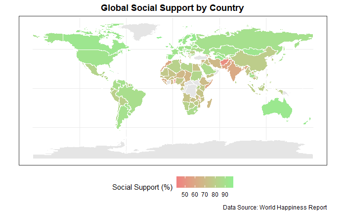

## 2.4 Freedom To Make Life Choices

The map below, titled “Global Freedom of Making Life Choices by Country,” visually represents the perceived freedom to make personal choices around the world. The color gradient highlights the variation in reported freedom across regions:

- *High levels* of perceived freedom are shown in green shades, with regions like North America, parts of Europe, and Oceania where individuals report a strong sense of autonomy in personal decision-making.
- *Low levels* of perceived freedom appear in red and orange shades, particularly in parts of Africa and Asia. This suggests that individuals in these areas may face greater restrictions or societal pressures, limiting their ability to make independent choices.
- *Grey regions* represent areas with no available data, notably in parts of the Middle East and other regions.

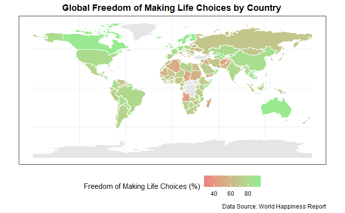

Overall, the global average perception of freedom sits around *75%*, leaving approximately **25%** of the world’s population feeling constrained in their ability to make personal choices. In many of the red-shaded countries, the lack of perceived freedom often relates to political restrictions. These areas commonly lack democratic elections or mechanisms for peaceful change of power, which can significantly impact individuals’ sense of personal autonomy. This map provides a compelling look into the intersections between social, political, and cultural factors that shape individual freedom worldwide.

## 2.5 Perception of Corruption

The map below, titled “Global Perception of Corruption by Country,” paints a somewhat bleak but realistic picture: corruption is everywhere, a global cancer eating away at society’s fabric. No political ideology seems immune—regardless of governance style, corruption has crept its way in, spoiling any chance at unblemished governance.

In red and orange, we see countries where corruption is perceived as highly prevalent. These colors dominate the map, reflecting how the majority of the world’s population acknowledges corruption as a serious, everyday influence that shapes policy, economics, and social interactions in profound ways. From North America to Australia, the perception of corruption is a universal theme.

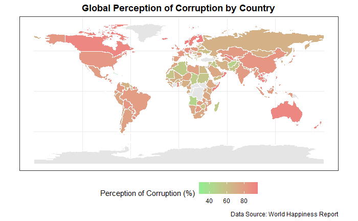

Overall, the global perception of corruption averages around *74.4%*, leaving approximately **25.6%** of the population under the impression that corruption is not an issue. This minority, living in a bubble of rare optimism, might enjoy a slightly rosier view of their leadership, but for the rest of us, corruption remains an ever-present, unwanted guest at the global table.

## 2.6 Generosity

All things considered, I believe that generosity is woven into a nation’s cultural and environmental fabric, passed down through generations. But as circumstances change, this inherited altruism often fades, molded by shifting priorities and life’s demands. It’s unrealistic to expect people to be cheerful and generous when their basic needs are unmet. As Bob Marley put it, ‘Them belly full, but we hungry,’ and ‘a hungry mob is an angry mob.’ When survival is the priority, anger tends to replace generosity.

The World Happiness Report captures this generosity factor through survey responses, particularly around prosocial behaviors like charitable donations, volunteering, and helping strangers. These responses, gathered by the Gallup World Poll, are averaged and normalized to reflect each country’s generosity score. However, generosity is only one part of a larger picture. Alongside factors like GDP per capita, social support, freedom, and perceptions of corruption, it helps construct a holistic view of well-being across nations, even though generosity itself plays a relatively small role in the overall happiness score

[figure not shown]

While some regions reflect strong prosocial values, the data suggests that there’s a significant portion of the population that sees room for growth in our collective generosity. It’s a reminder that, as a global community, we still have work to do in fostering compassion and supporting one another across borders and circumstances.

# 3 Answering the Question

## 3.1 Are We Really Happy

| mean_lifeladder | mean_LogGDP | mean_social | mean_life | mean_freedom | mean_gener | mean_corruption |
| --- | --- | --- | --- | --- | --- | --- |
| 5.48 | 9.4 | 80.94 | 63.4 | 75.03 | 38.71 | 74.397 |

In summary, the data provides a complex picture: the world’s population enjoys reasonably high social support and freedom but grapples with economic, health, and governance challenges. Corruption and limited generosity further dampen overall happiness, revealing a world where people are getting by but are not necessarily thriving. While some regions and communities may report higher life satisfaction, the global mean values indicate that many individuals experience constraints that prevent them from reaching a sense of full contentment.

So, are we really happy? Not entirely; while there’s enough stability and support to keep the global mood from tipping into widespread dissatisfaction, there’s still significant room for improvement in both personal and societal well-being. The data reflects a global citizenry that is cautiously content but increasingly aware of the systemic issues holding back collective happiness.

# 4 Conclusion

To conclude this analysis, I envision a couple of AI-powered machine learning projects that would extend and deepen the insights from this data.

The first project would focus on tracking and predicting each country’s happiness trend over time. By analyzing historical data and current indicators, the model could provide trendlines showing whether a country is improving or declining in overall happiness, social support, freedom, and other key metrics. This would give citizens, researchers, and policymakers a clearer view of their country’s direction in terms of well-being.

The second project would offer a more personalized experience. It would take user input on topics like social support, freedom, and perceptions of corruption—based on their personal opinions and experiences—and use this input to provide an individualized “happiness perception” score. This score would reflect how users perceive their environment’s quality, regardless of their country’s official metrics. It would be a tool for understanding personal satisfaction in relation to global data, giving users insights into their well-being in the context of the broader world.

Together, these AI projects could provide both macro and micro views of happiness, empowering individuals to understand and improve their well-being while also offering nations the insights they need to build happier societies.